# Data Analysis Process - Case Study 1 : (Part1: Import CSV file into Jupyter Notebook)

### (Wine Quality Data Set from UCI Machine Learning Lab)

[Wine Quality Datasets](https://archive.ics.uci.edu/ml/datasets/Wine+Quality)

P. Cortez, A. Cerdeira, F. Almeida, T. Matos and J. Reis. Modeling wine preferences by data mining from physicochemical properties. In Decision Support Systems, Elsevier, 47(4):547-553, 2009.

### You can Download this dataset from:

http://www3.dsi.uminho.pt/pcortez/wine/

## Attribute Information:

### Input variables (based on physicochemical tests):

1 - fixed acidity

2 - volatile acidity

3 - citric acid

4 - residual sugar

5 - chlorides

6 - free sulfur dioxide

7 - total sulfur dioxide

8 - density

9 - pH

10 - sulphates

11 - alcohol

### Output variable (based on sensory data):

12 - quality (score between 0 and 10)

# Questions relevant to this dataset

- What chemical characteristics are most important in predicting the quality of wine?
- Is a certain type of wine (red or white) associated with higher quality?
- Do wines with higher alcoholic content receive better ratings?
- Do sweeter wines (more residual sugar) receive better ratings?
- What level of acidity is associated with the highest quality?

# Let's Start !

## How to import CSV file into Jupyter Notebook?

First make sure CSV Files are in the same directory as your Jupyter Notebook, and then try follwing Codes:

> > import pandas as pd

> > csvfile = pd.read_csv('winequality-red.csv', sep= ';')

> > csvfile.head()

If the files are not in the same directory as your Jupyter Notebook, write the path in which your files are located. In this case the path is:

```
       /home/bahar/Documents/All Data/winequality/winequality-red.csv
```

> > import pandas as pd

> > csvfile = pd.read_csv('/home/bahar/Documents/All Data/winequality/winequality-red.csv', sep= ';')

> > csvfile.head()

#### what doeas sep= ';' do?

- It is crucial to use correct Delimiter
- Without it, the result looks messy

#### what does csvfile.head() do?

- It just shows the first few rows of csvfile

#### what does %matplotlib inline do?

- to view plots

```python
# importing CSV file into Jupyter Notebook


import pandas as pd

#add following code to view plots
%matplotlib inline

# my files are not in the same directory as my Jupyter Notebok
csvfile = pd.read_csv('/home/bahar/Documents/All Data/winequality/winequality-red.csv')

#Just shows the first few rows of csvfile
csvfile.head()
```

|  | fixed acidity;"volatile acidity";"citric acid";"residual sugar";"chlorides";"free sulfur dioxide";"total sulfur dioxide";"density";"pH";"sulphates";"alcohol";"quality" |
| --- | --- |
| 0 | 7.4;0.7;0;1.9;0.076;11;34;0.9978;3.51;0.56;9.4;5 |
| 1 | 7.8;0.88;0;2.6;0.098;25;67;0.9968;3.2;0.68;9.8;5 |
| 2 | 7.8;0.76;0.04;2.3;0.092;15;54;0.997;3.26;0.65;... |
| 3 | 11.2;0.28;0.56;1.9;0.075;17;60;0.998;3.16;0.58... |
| 4 | 7.4;0.7;0;1.9;0.076;11;34;0.9978;3.51;0.56;9.4;5 |

## How should we Solve the problem of messy data?

- By adding sep= ';'

```python
#importing data related to Red Wine


redwine = pd.read_csv("/home/bahar/Documents/All Data/winequality/winequality-red.csv", sep= ';')

redwine.head()
```

|  | fixed acidity | volatile acidity | citric acid | residual sugar | chlorides | free sulfur dioxide | total sulfur dioxide | density | pH | sulphates | alcohol | quality |
| --- | --- | --- | --- | --- | --- | --- | --- | --- | --- | --- | --- | --- |
| 0 | 7.4 | 0.70 | 0.00 | 1.9 | 0.076 | 11.0 | 34.0 | 0.9978 | 3.51 | 0.56 | 9.4 | 5 |
| 1 | 7.8 | 0.88 | 0.00 | 2.6 | 0.098 | 25.0 | 67.0 | 0.9968 | 3.20 | 0.68 | 9.8 | 5 |
| 2 | 7.8 | 0.76 | 0.04 | 2.3 | 0.092 | 15.0 | 54.0 | 0.9970 | 3.26 | 0.65 | 9.8 | 5 |
| 3 | 11.2 | 0.28 | 0.56 | 1.9 | 0.075 | 17.0 | 60.0 | 0.9980 | 3.16 | 0.58 | 9.8 | 6 |
| 4 | 7.4 | 0.70 | 0.00 | 1.9 | 0.076 | 11.0 | 34.0 | 0.9978 | 3.51 | 0.56 | 9.4 | 5 |

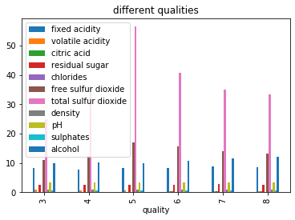

```python
redwine.groupby('quality').mean().plot(kind='bar', title='different qualities')
```

```python
#importing data related to White Wine


whitewine = pd.read_csv("/home/bahar/Documents/All Data/winequality/winequality-white.csv", sep=';')
whitewine.head()
```

|  | fixed acidity | volatile acidity | citric acid | residual sugar | chlorides | free sulfur dioxide | total sulfur dioxide | density | pH | sulphates | alcohol | quality |
| --- | --- | --- | --- | --- | --- | --- | --- | --- | --- | --- | --- | --- |
| 0 | 7.0 | 0.27 | 0.36 | 20.7 | 0.045 | 45.0 | 170.0 | 1.0010 | 3.00 | 0.45 | 8.8 | 6 |
| 1 | 6.3 | 0.30 | 0.34 | 1.6 | 0.049 | 14.0 | 132.0 | 0.9940 | 3.30 | 0.49 | 9.5 | 6 |
| 2 | 8.1 | 0.28 | 0.40 | 6.9 | 0.050 | 30.0 | 97.0 | 0.9951 | 3.26 | 0.44 | 10.1 | 6 |
| 3 | 7.2 | 0.23 | 0.32 | 8.5 | 0.058 | 47.0 | 186.0 | 0.9956 | 3.19 | 0.40 | 9.9 | 6 |
| 4 | 7.2 | 0.23 | 0.32 | 8.5 | 0.058 | 47.0 | 186.0 | 0.9956 | 3.19 | 0.40 | 9.9 | 6 |

## What happens if we remove .head()?

Let's remove it and see what happens:

- now, you can see the few last lines

```python
csvfile = pd.read_csv("/home/bahar/Documents/All Data/winequality/winequality-white.csv", sep=';')
csvfile
```

|  | fixed acidity | volatile acidity | citric acid | residual sugar | chlorides | free sulfur dioxide | total sulfur dioxide | density | pH | sulphates | alcohol | quality |
| --- | --- | --- | --- | --- | --- | --- | --- | --- | --- | --- | --- | --- |
| 0 | 7.0 | 0.27 | 0.36 | 20.7 | 0.045 | 45.0 | 170.0 | 1.00100 | 3.00 | 0.45 | 8.8 | 6 |
| 1 | 6.3 | 0.30 | 0.34 | 1.6 | 0.049 | 14.0 | 132.0 | 0.99400 | 3.30 | 0.49 | 9.5 | 6 |
| 2 | 8.1 | 0.28 | 0.40 | 6.9 | 0.050 | 30.0 | 97.0 | 0.99510 | 3.26 | 0.44 | 10.1 | 6 |
| 3 | 7.2 | 0.23 | 0.32 | 8.5 | 0.058 | 47.0 | 186.0 | 0.99560 | 3.19 | 0.40 | 9.9 | 6 |
| 4 | 7.2 | 0.23 | 0.32 | 8.5 | 0.058 | 47.0 | 186.0 | 0.99560 | 3.19 | 0.40 | 9.9 | 6 |
| ... | ... | ... | ... | ... | ... | ... | ... | ... | ... | ... | ... | ... |
| 4893 | 6.2 | 0.21 | 0.29 | 1.6 | 0.039 | 24.0 | 92.0 | 0.99114 | 3.27 | 0.50 | 11.2 | 6 |
| 4894 | 6.6 | 0.32 | 0.36 | 8.0 | 0.047 | 57.0 | 168.0 | 0.99490 | 3.15 | 0.46 | 9.6 | 5 |
| 4895 | 6.5 | 0.24 | 0.19 | 1.2 | 0.041 | 30.0 | 111.0 | 0.99254 | 2.99 | 0.46 | 9.4 | 6 |
| 4896 | 5.5 | 0.29 | 0.30 | 1.1 | 0.022 | 20.0 | 110.0 | 0.98869 | 3.34 | 0.38 | 12.8 | 7 |
| 4897 | 6.0 | 0.21 | 0.38 | 0.8 | 0.020 | 22.0 | 98.0 | 0.98941 | 3.26 | 0.32 | 11.8 | 6 |

4898 rows × 12 columns

# Appending Data

### 1. By using NumPy:

- create a new column (preserves color information, whether red or white)

### 2. By using pandas:

- combine two datasets

```python
import pandas as pd

# Define a dictionary containing Students data
color = {}

# Convert the dictionary into DataFrame
df = pd.DataFrame(color)

# Declare a list that is to be converted into a column
color = ['white', 'red']

# Using 'Address' as the column name
# and equating it to the list
df['Address'] = address
```